# 电影推荐引擎》》》基于ALS算法 实现协同过滤式推荐

### Hadoop3.3 + Spark3.0 + IPython3.7 机器学习与大数据实战

## 电影推荐引擎 >>> 基于ALS算法 实现协同过滤式推荐

### 策略制定及验证：张君颖 ； 报告日期：2020.12.16

作者邮箱：zhang.jun.ying@outlook.com

项目源代码、数据、自定义函数已上传GitHub：

https://github.com/lotbear/Python-Financial-investment-strategy

=======================================================================

### 常用的推荐引擎算法介绍

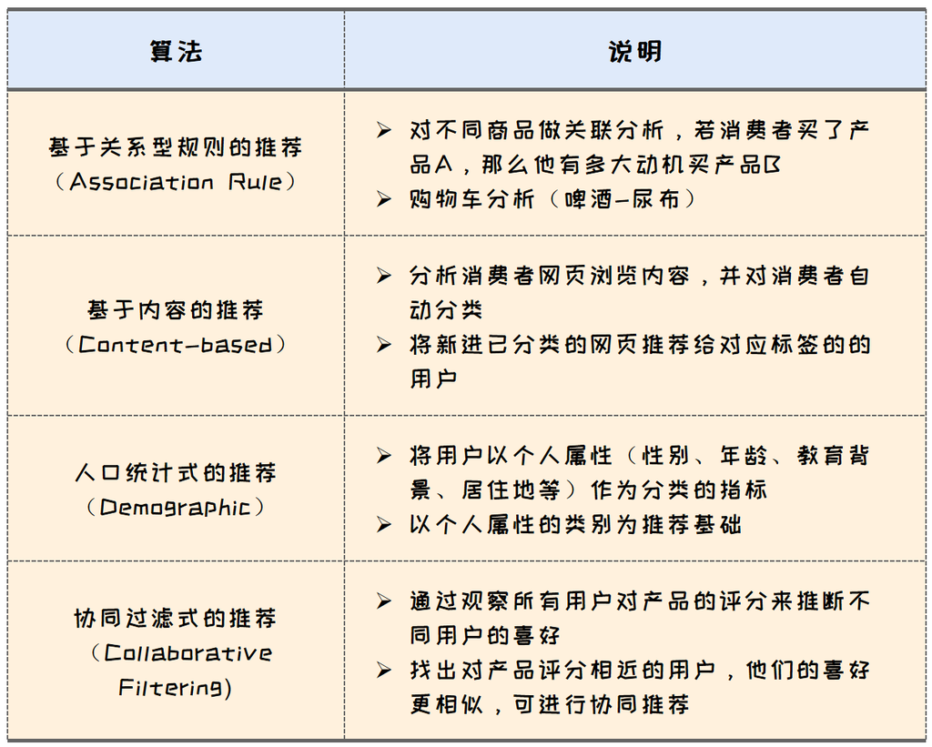

### 协同过滤式推荐的优缺点

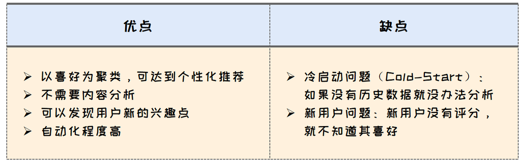

#### 互联网应用场景中，一般使用混合式的方法，可以达到互补的效果，进而给用户更好的个性化推荐体验。

### 电影推荐引擎 >>> 数据描述

数据来源：https://grouplens.org/datasets/movielens/

GroupLens 实验室隶属于明尼苏达大学，MovieLens 网站是其中一个项目，该项目主要通过使用协同过滤技术 向会员推荐电影，是一个推荐系统和虚拟社区网站。

由于完整版的用户观影数据较大，对服务器的配置要求较高，因此，我们选择较小版本的数据集进行算法测试。

[figure not shown]

通过该网站下载的数据包中有 4 个 csv 格式文件，一个 README 文本，README中介绍了数据的大致情况。

具体来看，4 个数据文件夹，包含了 14 个参数变量，通用的索引变量 3个（ userId / movieId / timestamp ）。

#### 1. tags 文件主要展示不同用户，看过的不同电影，以及这些电影的风格，观影时间。

tags.csv: userId（用户id），movieId（电影id)，tag（电影风格），timestamp（观影时间）

#### 2. links 文件主要展示 “ 同一部电影，其他观影网站可被链接的电影数据 id “。

links.csv: movieId（电影id），imdbId（<imdb.com> 网站上对应的电影 id），tmdbId（<themoviedb.org> 网站上对应的电影 id）

#### 3. movies 文件主要展示不同电影 id 所对应的电影片名 和 电影类型。

movies.csv: movieId（电影id），title（电影片名），genres（电影类型）

#### 4. ratings：不同用户，看过的电影 id，并给予的评分，以及观影时间。

ratings.csv: userId（用户id），movieId（电影id），rating（评分），timestamp（观影时间）

### 电影推荐引擎 >>> 项目分析

#### 拿到数据后，我们首先要 “ 分析问题 ”：

电影推荐是一种个性化的推荐机制，其核心是用户的兴趣和偏好。

我们目前掌握的数据中，genres（电影类型）/ tag（电影风格）是人为设置的电影标签数据，并非用户观影反馈数据，如果以这两个标签作为推荐参考，可能有些机械化，不能更动态地捕捉用户偏好和新的兴趣点。

#### 因此，我们设计的推荐解决方案是：引入 “ 协同过滤筛选机制 ”：

通过观察所有观影用户 对同一影片的评分，推断每个用户的喜好，并将评分相似的用户定义为喜好相似的用户，在喜好相似的用户中，若有人看过某一影片，且给出了高分，那么就将该影片推荐给其他相同喜好，但还未观影的用户。

本次报告，我们选用 2 个数据文件，6 个参数变量，来进行协同过滤式推荐算法的实战：

movies.csv ： movieId（电影id)，title（电影片名）  
ratings.csv ： userId（用户id），movieId（电影id)，ranting（评分），timestamp（观影时间）

### 电影推荐引擎 >>> 算法实战

#### 第一步：数据上传 Hadoop-HDFS 分布式平台后，用 Saprk 命令读取/查看/处理。

```python
# 查看 Spark 的运行模式，本次算法基于 Hadoop-yarn 架构
# 实现 4 台虚拟机同步进行的分布式运算
print('查看 Spark 的运行模式：',str(sc.master))
```

```
查看 Spark 的运行模式： yarn
```

```python
# 设置全局数据集的路径
# 若 sc.master 查看显示的运行模式为 "local",则使用本地数据集
# 若 sc.master 查看显示的运行模式为其他，如 "yarn"，"spark://master:7077"(Standalone模式)
# 则选择 HDFS 上的数据集
global Path
if sc.master[0:5]=="local" :
   Path="file:/home/lotbear/Big-Data/movie_rec/"
else:
   Path="hdfs://master:9000/user/lotbear/data/movie_rec/"
```

```python
# 将 ratings 数据读取为 rawUserData（原始用户数据）
rawUserData = sc.textFile(Path+"ratings.csv")
print('用户电影评分数据量：',rawUserData.count())
```

```
用户电影评分数据量： 100837
```

```python
# 读取 rawUserData 前 5 行数据
for x in rawUserData.take(5):
    print(x)
```

```
userId,movieId,rating,timestamp
1,1,4.0,964982703
1,3,4.0,964981247
1,6,4.0,964982224
1,47,5.0,964983815
```

```python
# 删除首行 “表头” 数据
header = rawUserData.first()
rawUserData = rawUserData.filter(lambda x:x !=header)
rawUserData.take(5)
```

```
['1,1,4.0,964982703',
 '1,3,4.0,964981247',
 '1,6,4.0,964982224',
 '1,47,5.0,964983815',
 '1,50,5.0,964982931']
```

```python
# 通过 map 命令,读取 rawUserData 前 3个字段数据
# 转换成新的 RDD 数据: rawRatings
rawRatings = rawUserData.map(lambda line: line.split(",")[:3] )
print('rawRatings 数据类型：',type(rawRatings))
rawRatings.take(5)
```

```
rawRatings 数据类型： <class 'pyspark.rdd.PipelinedRDD'>
```

```
[['1', '1', '4.0'],
 ['1', '3', '4.0'],
 ['1', '6', '4.0'],
 ['1', '47', '5.0'],
 ['1', '50', '5.0']]
```

#### 由于 ALS 训练数据的格式为 Rating RDD:

Rating ( user , product , rating )  
因此，我们需要对数据进一步处理

```python
# 导入 Rating 模块
from pyspark.mllib.recommendation import Rating
ratingsRDD = rawRatings.map(lambda x: (x[0],x[1],x[2]))
ratingsRDD.take(5)
```

```
[('1', '1', '4.0'),
 ('1', '3', '4.0'),
 ('1', '6', '4.0'),
 ('1', '47', '5.0'),
 ('1', '50', '5.0')]
```

```python
# 定义变量 numRatings 评分数量
numRatings = ratingsRDD.count()
numRatings
```

```
100836
```

```python
# 定义变量 numUsers 用户数量（去重）
numUsers = ratingsRDD.map(lambda x: x[0] ).distinct().count()
numUsers
```

```
610
```

```python
# 定义变量 numMovies 电影数量（去重）
numMovies = ratingsRDD.map(lambda x: x[1]).distinct().count()
numMovies
```

```
9724
```

```python
# RDD 数据持久化，方便多次调用
ratingsRDD.persist()
```

```
PythonRDD[19] at RDD at PythonRDD.scala:53
```

#### 第二步：导入 ALS 算法训练模型

```python
from pyspark.mllib.recommendation import ALS
```

#### ALS.train() 可以分为显式评分 和 隐式评分

ALS.train ( ratings, rank, iterations=5, lambda=0.01 )  
ALS.trainImplicit ( ratings, rank, iterations=5, lambda=0.01 )  
其中，rank 参数为矩阵分解参数，iterations 为算法重复次数，lambda 为阈值

两个模型，均返回 MatrixFactorizationModel 模型：  
rank: 分解的参数  
userFeatures: 分解后用户矩阵 X（ m * rank )  
productFeatures: 分解后产品矩阵 Y（ rank * n )  
原数据矩阵： A （ m * n )

```python
model = ALS.train(ratingsRDD, 10, 10, 0.01)
print(model)
```

```
<pyspark.mllib.recommendation.MatrixFactorizationModel object at 0x7efefc598c18>
```

### 电影推荐引擎 >>> 使用训练好的模型进行电影推荐

#### 当我们想对同一用户进行多部电影推荐时

#### recommendProducts 函数可以帮我们找到用户可能最感兴趣的电影，并进行排名

函数 recommendProducts( user:Int, num:Int )

其中 user 为要被推荐的用户 id , num 为推荐的电影数量

推荐的电影会以 “评分” 从高到低 进行自动排序

```python
model.recommendProducts(101,5)
```

```
[Rating(user=101, product=1354, rating=8.547775151630326),
 Rating(user=101, product=61240, rating=7.0235667804659165),
 Rating(user=101, product=116897, rating=6.848953777481393),
 Rating(user=101, product=7587, rating=6.822385808483451),
 Rating(user=101, product=2239, rating=6.800370072222392)]
```

```python
# 我们可以从模型中，查找给用户推荐的特定电影的评分
# 如：userID=100, movieID=179819, 查看评分 rating 的值
model.predict(101, 179819)
```

```
5.773527191827356
```

#### 当我们想促销某部电影时

#### recommendUsers 函数可以帮我们找到对这部电影最感兴趣的用户，并进行排名

```python
model.recommendUsers(product=110,num=5)
```

```
[Rating(user=53, product=110, rating=6.977144521639186),
 Rating(user=543, product=110, rating=5.598110428734583),
 Rating(user=360, product=110, rating=5.594789849108189),
 Rating(user=364, product=110, rating=5.5715959182777475),
 Rating(user=337, product=110, rating=5.523103634928935)]
```

### 电影推荐引擎 >>> 显示推荐的电影的名称

```python
itemRDD = sc.textFile(Path+"movies.csv")
print('电影数据总量：',itemRDD.count())
```

```
电影数据总量： 9743
```

```python
# 读取 rawUserData 前 5 行数据
for x in itemRDD.take(5):
    print(x)
```

```
movieId,title,genres
1,Toy Story (1995),Adventure|Animation|Children|Comedy|Fantasy
2,Jumanji (1995),Adventure|Children|Fantasy
3,Grumpier Old Men (1995),Comedy|Romance
4,Waiting to Exhale (1995),Comedy|Drama|Romance
```

```python
# 删除首行 “表头” 数据
header = itemRDD.first()
itemRDD = itemRDD.filter(lambda x:x !=header)
itemRDD.take(5)
```

```
['1,Toy Story (1995),Adventure|Animation|Children|Comedy|Fantasy',
 '2,Jumanji (1995),Adventure|Children|Fantasy',
 '3,Grumpier Old Men (1995),Comedy|Romance',
 '4,Waiting to Exhale (1995),Comedy|Drama|Romance',
 '5,Father of the Bride Part II (1995),Comedy']
```

```python
# 将电影id 与 电影名，生成 字典数据形式，方便调取
movieTitle= itemRDD.map( lambda line : line.split(","))\
                                   .map(lambda a: (float(a[0]),a[1]))\
                                   .collectAsMap()
print('movieTitle 数据类型:',type(movieTitle))
print('数据量：',len(movieTitle))
```

```
movieTitle 数据类型: <class 'dict'>
数据量： 9742
```

```python
# 显示前 5 部电影名
for i in range(1,6):
    print(str(i)+":"+movieTitle[i])
```

```
1:Toy Story (1995)
2:Jumanji (1995)
3:Grumpier Old Men (1995)
4:Waiting to Exhale (1995)
5:Father of the Bride Part II (1995)
```

### >>> 为用户个性化推荐电影

### 为 id=101 的用户，推荐 10 部电影

### 并预测其对该电影的满意度 / 评分，按从高到低排序

```python
RecommendMovies= model.recommendProducts(101,10)
for m in RecommendMovies:
    print("对用户"+ str(m[0]) + \
          "，推荐电影："+ str(movieTitle[m[1]]) + \
          "，\n推荐评分："+ str(m[2]))
    print('='*50)
```

```
对用户101，推荐电影：Breaking the Waves (1996)，
推荐评分：8.547775151630326
==================================================
对用户101，推荐电影：Let the Right One In (Låt den rätte komma in) (2008)，
推荐评分：7.0235667804659165
==================================================
对用户101，推荐电影：Wild Tales (2014)，
推荐评分：6.848953777481393
==================================================
对用户101，推荐电影："Samouraï，
推荐评分：6.822385808483451
==================================================
对用户101，推荐电影：Swept Away (Travolti da un insolito destino nell'azzurro mare d'Agosto) (1975)，
推荐评分：6.800370072222392
==================================================
对用户101，推荐电影：Public Enemies (2009)，
推荐评分：6.774216170666146
==================================================
对用户101，推荐电影：Inside Job (2010)，
推荐评分：6.77358663650449
==================================================
对用户101，推荐电影：Deconstructing Harry (1997)，
推荐评分：6.581445573845701
==================================================
对用户101，推荐电影：Split (2017)，
推荐评分：6.49950209981287
==================================================
对用户101，推荐电影：Igby Goes Down (2002)，
推荐评分：6.45149947417833
==================================================
```

### >>> 为电影推广，寻找潜在用户

### 为 id=202 的电影，寻找 10 位可能感兴趣的用户

### 并预测用户对该电影的满意度 / 评分，按从高到低排序

```python
RecommendUser = model.recommendUsers(202, 10)
print("针对电影id:202 , 电影名:{0}推荐下列用户id:". \
        format(movieTitle[202]))
print(' ')
for u in RecommendUser:
        print("针对用户id {0}  推荐评分 {1}".format( u[0],u[2]))
        print('='*50)
```

```
针对电影id:202 , 电影名:Total Eclipse (1995)推荐下列用户id:

针对用户id 301  推荐评分 4.546316847444679
==================================================
针对用户id 393  推荐评分 4.419571323079257
==================================================
针对用户id 138  推荐评分 4.243625032404518
==================================================
针对用户id 295  推荐评分 4.189083167022634
==================================================
针对用户id 467  推荐评分 4.153077030931658
==================================================
针对用户id 224  推荐评分 4.0035934962164585
==================================================
针对用户id 403  推荐评分 3.9444925188114652
==================================================
针对用户id 548  推荐评分 3.8390845637413804
==================================================
针对用户id 530  推荐评分 3.8335214407387648
==================================================
针对用户id 572  推荐评分 3.8176448025680476
==================================================
```

### >>> 本报告运行的软件架构

Linux-Ubuntu 20.10 + Hadoop 3.3 + Spark 3 + Java 11 + Scala 2.12 + Python 3.7 + Anaconda 3

1 台 master 主机，负责 HDFS：NameNode + MapReduce（Yarn）：ResourceManager

3 台 data 辅助计算机，负责 HDFS：DataNode + MapReduce（Yarn）：NodeManager

所有 HDFS 文件分布式存储在 4 台电脑上，且各有 3 份备份

具体配置过程，请参见作者另一篇报告《Hadoop+Spark+IPython>>>RDD大数据分布式运算（基础篇）》

### 查看 HDFS 分布式数据平台，数据存储情况：

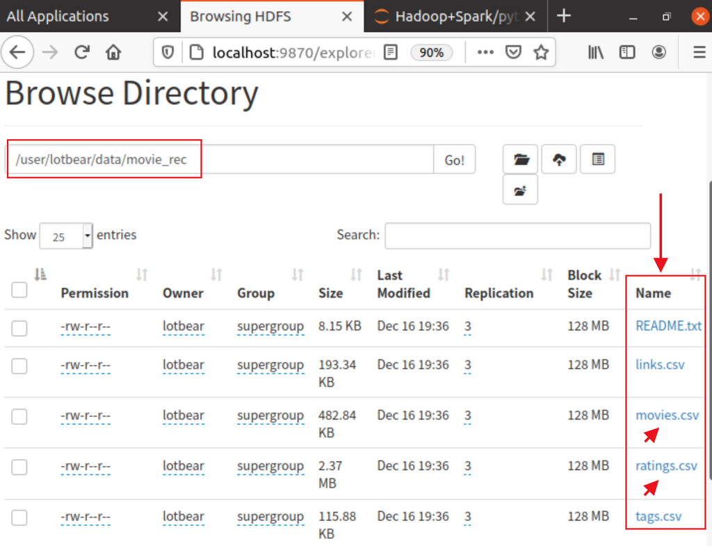

### 查看 Hadoop 大数据架构 + 电影推荐引擎项目运行情况：

[figure not shown]